# Understanding Full Frame Images

## Learning Goals

In this tutorial we will learn the following,

- What a TESS Full Frame Image (FFI) is.
- How to obtain an FFI from the [MAST archive](https://archive.stsci.edu/tess/) via *Lightkurve*.
- How to cut out data around an object of interest in an FFI.
- How to plot the cut FFI data.
- How to access the metadata, and understand the files properties and units.

We will also show the user where they can find more details about TESS FFIs.

## What is a Full Frame Image?

The *TESS* telescope observes stars for long periods of time, just under a month per sector. Each sector is covered by 4 cameras.

A single FFI is the full set of all science and collateral pixels across all CCDs of a given camera. FFIs were taken every 30 minutes during science operations in the primary mission, and every 10 min in the extended.

FFI data is provided in three types: uncalibrated, calibrated, and uncertainty.

Uncalibrated FFI data is provided in one file with two Header/Data Units (HDUs): a primary header and the CCD image header and data.

The calibrated image and its uncertainty are provided in a separate file with several HDUs: a primary header, the CCD calibrated image header and data, the CCD uncertainty image header and data, and the cosmic ray corrections binary table header and data.

Cosmic Ray Mitigated (CRM) FFIs are the same as FFIs except they will are collected with the on-board cosmic ray mitigation enabled.

Sometimes an object of interest isn't in a TPF (see the TPF tutorial) but is in an FFI and as such the user may wish to create a cut out of the object in this FFI and work with this object only.

In this tutorial we'll cover the basics of working with FFIs.

## Imports

This tutorial requires that you import *Lightkurve* only.

```python
%matplotlib inline
import lightkurve as lk
```

## Defining Terms

- Target Pixel File (TPF): A file containing the original CCD pixel observations from which light curves are extracted.
- Full Frame Image (FFI): A file containing the full set of all science and collateral pixels across all CCDs of a given camera.
- Cadence: The rate at which TESS photometric observations are stored.
- Sector: One of TESS's 27 (to date) observing periods, approximately ~27 days in duration.

## Downloading Data

The *TESS* FFIs are stored on the [Mikulksi Archive for Space Telescopes](https://archive.stsci.edu/tess/) (MAST) archive.

First, let's create a TPF for an object of interest, let's choose Gaia object DR25290850609994130560. This object was observed in the *TESS* FFI data only. We'll use the [`search_tesscut`](https://docs.lightkurve.org/api/lightkurve.search.search_tesscut.html) function to download a cut out of the target in a chosen sector. You can determine which sectors the target was observed in using the [MAST TESS portal](https://mast.stsci.edu/portal/Mashup/Clients/Mast/Portal.html).

```python
search_result = lk.search_tesscut('Gaia DR25290850609994130560')
print(search_result)
```

```
SearchResult containing 5 data products.

 #   observation   author         target_name         productFilename distance
--- -------------- ------ --------------------------- --------------- --------
  0  TESS Sector 4   MAST Gaia DR25290850609994130560         TESSCut      0.0
  1  TESS Sector 7   MAST Gaia DR25290850609994130560         TESSCut      0.0
  2  TESS Sector 8   MAST Gaia DR25290850609994130560         TESSCut      0.0
  3  TESS Sector 9   MAST Gaia DR25290850609994130560         TESSCut      0.0
  4 TESS Sector 10   MAST Gaia DR25290850609994130560         TESSCut      0.0
```

We can see that this object is detected in Sectors 4, 7, 8, 9, and 10. You can download data from just one sector and specify the cutout_size in number of TESS pixels on a side as an argument to `.download()`. The default is a meager 5 × 5 square. Let’s go with 10 pixels square.

```python
search_result_s4 = lk.search_tesscut('Gaia DR25290850609994130560', sector=4)
tpfs_s4 = search_result_s4.download(cutout_size=10)
print(tpfs_s4)
```

```
TessTargetPixelFile(TICID: Gaia DR25290850609994130560)
```

The above code has created a variable named `tpfs_s4` which is a Python object of type `TessTargetPixelFile` This can then be treated and examined the same way as in the previous Target Pixel File tutorial, for example lets plot the object.

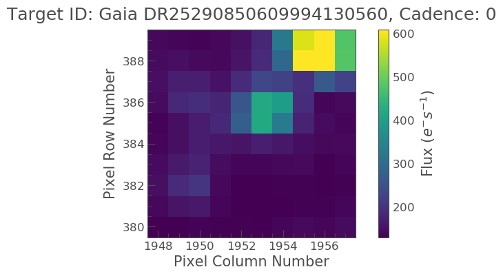

```python
%matplotlib inline
tpfs_s4.plot();
```

Great we now see our object of interest and the surrounding region. As indicated in the previous Target Pixel File tutorial, we can examine the header of this file via,

```python
tpfs_s4.hdu[1].header
```

```
XTENSION= 'BINTABLE'           / binary table extension
BITPIX  =                    8 / array data type
NAXIS   =                    2 / number of array dimensions
NAXIS1  =                 2066 / length of dimension 1
NAXIS2  =                 1060 / length of dimension 2
PCOUNT  =                    0 / number of group parameters
GCOUNT  =                    1 / number of groups
TFIELDS =                   12 / number of table fields
TTYPE1  = 'TIME    '           / column name
TFORM1  = 'D       '           / column format
TUNIT1  = 'BJD - 2457000, days' / unit
TDISP1  = 'D14.7   '           / display format
TTYPE2  = 'TIMECORR'           / column name
TFORM2  = 'E       '           / column format
TUNIT2  = 'd       '           / unit
TDISP2  = 'E14.7   '           / display format
TTYPE3  = 'CADENCENO'          / column name
TFORM3  = 'J       '           / column format
TDISP3  = 'I10     '           / display format
TTYPE4  = 'RAW_CNTS'           / column name
TFORM4  = '100J    '           / column format
TUNIT4  = 'count   '           / unit
TNULL4  =                   -1 / null value
TDISP4  = 'I8      '           / display format
TDIM4   = '(10, 10)'           / multi-dimensional array spec
WCAX4   =                    2 / number of WCS axes
1CTYP4  = 'RA---TAN'           / right ascension coordinate type
2CTYP4  = 'DEC--TAN'           / declination coordinate type
1CRPX4  =      5.4970243878873 / [pixel] reference pixel along image axis 1
2CRPX4  =      5.5084913439498 / [pixel] reference pixel along image axis 2
1CRVL4  =      120.49774824319 / [deg] right ascension at reference pixel
2CRVL4  =      -60.35838348711 / [deg] declination at reference pixel
1CUNI4  = 'deg     '           / physical unit in column dimension
2CUNI4  = 'deg     '           / physical unit in row dimension
1CDLT4  =                  1.0 / [deg] pixel scale in RA dimension
2CDLT4  =                  1.0 / [deg] pixel scale in DEC dimension
11PC4   =  0.00082008272000062 / Coordinate transformation matrix element
12PC4   =  -0.0052652158454813 / Coordinate transformation matrix element
21PC4   =   0.0052951771787336 / Coordinate transformation matrix element
22PC4   =   0.0012306942427273 / Coordinate transformation matrix element
```

[output cut: 224 more lines]

```
OBJECT  = '' / string version of target id
TCID    =                    0 / unique tess target identifier
PXTABLE =                    0 / pixel table id
PMRA    =                  0.0 / [mas/yr] RA proper motion
PMDEC   =                  0.0 / [mas/yr] Dec proper motion
PMTOTAL =                  0.0 / [mas/yr] total proper motion
TESSMAG =                  0.0 / [mag] TESS magnitude
TEFF    =                  0.0 / [K] Effective temperature
LOGG    =                  0.0 / [cm/s2] log10 surface gravity
MH      =                  0.0 / [log10([M/H])] metallicity
RADIUS  =                  0.0 / [solar radii] stellar radius
TICVER  =                    0 / TICVER
TICID   = '' / unique tess target identifier
CHECKSUM= 'f752h751f751f751'   / HDU checksum updated 2020-08-26T14:10:38
DATASUM = '3805688324'         / data unit checksum updated 2020-08-26T14:10:38
```

We can also examine specific things like the flux or time via,

```python
tpfs_s4.flux
```

$[[[129.99297,~128.63951,~132.87094,~\dots,~139.99612,~137.95688,~142.58392],~ [138.64349,~153.85022,~161.18605,~\dots,~132.13853,~131.88116,~136.26653],~ [147.42535,~185.44145,~202.03874,~\dots,~131.27419,~129.55354,~132.28387],~ \dots,~ [148.45624,~168.75594,~169.70703,~\dots,~193.291,~262.43341,~225.49281],~ [143.34943,~148.85297,~140.99071,~\dots,~632.60272,~1230.0093,~481.08664],~ [138.4722,~136.3645,~133.1722,~\dots,~582.95276,~1186.0709,~478.35709]],~ [[129.82346,~128.34328,~132.64188,~\dots,~139.19876,~137.08186,~142.32404],~ [139.79184,~152.97951,~161.24356,~\dots,~132.91368,~131.2858,~136.80386],~ [147.51363,~185.70856,~202.45325,~\dots,~131.01465,~129.47301,~132.81329],~ \dots,~ [147.99286,~167.25301,~168.89616,~\dots,~194.54517,~264.9231,~225.16179],~ [143.70619,~149.3633,~140.49521,~\dots,~632.60107,~1227.5686,~482.08145],~ [138.03108,~136.32384,~133.2,~\dots,~582.40741,~1182.1221,~479.85046]],~ [[129.21542,~129.74716,~132.78502,~\dots,~138.40413,~137.88484,~143.00275],~ [139.7187,~155.0994,~160.00632,~\dots,~132.12894,~131.79468,~136.66957],~ [147.73445,~183.78162,~200.47708,~\dots,~130.74011,~129.2097,~132.41162],~ \dots,~ [147.66319,~166.57088,~168.81226,~\dots,~215.93103,~281.56219,~224.84123],~ [142.83057,~148.42052,~140.91992,~\dots,~642.88855,~1205.141,~467.6749],~ [137.69144,~135.93571,~133.34496,~\dots,~573.22418,~1151.689,~483.14612]],~ \dots,~ [[792.39258,~789.263,~795.30682,~\dots,~809.82086,~811.76941,~815.80994],~ [803.67145,~809.58545,~835.54602,~\dots,~800.33563,~802.27563,~808.07153],~ [803.70325,~832.35767,~866.13525,~\dots,~802.09814,~800.79468,~804.69025],~ \dots,~ [799.46198,~814.78491,~819.1286,~\dots,~869.16278,~1009.9353,~943.88312],~ [794.48761,~799.0069,~792.25012,~\dots,~1211.3436,~2031.7046,~1349.0428],~ [790.42419,~785.95496,~787.04718,~\dots,~1130.4243,~1644.5442,~1246.1456]],~ [[813.54431,~809.97974,~817.47009,~\dots,~830.65527,~830.61475,~836.75928],~ [826.25146,~831.77899,~856.91522,~\dots,~821.61914,~823.5957,~828.23602],~ [825.62567,~854.96924,~889.86981,~\dots,~822.89606,~820.79828,~824.80457],~ \dots,~ [821.97601,~836.54681,~844.15063,~\dots,~892.07336,~1033.9146,~965.64771],~ [816.31024,~823.79694,~816.89545,~\dots,~1233.7531,~2053.4348,~1371.8173],~ [813.43365,~809.15466,~809.1488,~\dots,~1154.3142,~1664.0698,~1269.6807]],~ [[843.42645,~838.84576,~847.90161,~\dots,~861.24701,~861.25537,~867.8017],~ [855.00861,~862.23065,~888.0213,~\dots,~849.95538,~852.78198,~859.7309],~ [856.35095,~883.28583,~919.44934,~\dots,~852.11145,~851.24445,~854.23767],~ \dots,~ [849.98053,~867.28394,~872.92499,~\dots,~923.02142,~1061.4458,~994.54596],~ [847.56006,~852.9693,~846.55609,~\dots,~1264.6205,~2082.7625,~1403.7192],~ [843.9043,~838.604,~839.48645,~\dots,~1181.7628,~1696.9923,~1301.2625]]] \; \mathrm{\frac{e^{-}}{s}}$